# Exercise_one.R

zhian

Mon Nov 17 15:30:11 2014

# Exercise One: Basic Recursion

There are three tasks in this exercise:

1. Construct the fibonacci algorithm and make a table with N, the fibonacci number, and the result of CALL_COUNTER.
2. Construct a factorial algorithm and create the same table.
3. Construct a terminal function to calculate the $n^{th}$ triangular number.

## Packages and global variables

```r
library(knitr)
library(ggplot2)
library(reshape2)
CALL_COUNTER <- 0
```

## Fibonacci function

### Definition

```r
fib <- function(n, call_count = TRUE){
  if (call_count){
    CALL_COUNTER <<- CALL_COUNTER + 1
  }
  if (n == 1 || n == 2){
    return(1)
  } else {
    a <- fib(n - 1)
    b <- fib(n - 2)
    c <- a + b
    return(c)
  }
}
```

### Initial tests

Now that we have the function, we should run it to make sure everything works

```r
fib(1)
```

```
## [1] 1
```

```r
fib(2)
```

```
## [1] 1
```

```r
fib(8)
```

```
## [1] 21
```

```r
fib(10)
```

```
## [1] 55
```

### Creating table

Excellent, now let’s see what happens from 1 to 20. Here I am setting a maximum number, creating a data frame to hold the results, and making a for loop to loop through all the numbers.

```r
n <- 20
restab <- data.frame(list(n = 1:n,
                          `Fibonacci number` = 1:n,
                          `Number of Calls` = 1:n),
                     check.names = FALSE)
for (i in 1:n){
  CALL_COUNTER <- 0
  fib_res      <- fib(i)
  restab[i, ]  <- c(i, fib_res, CALL_COUNTER)
}
```

### Pretty things

Now I’m using kable from the package knitr to make the results pretty and I’m plotting with ggplot2 and reshape2

```r
knitr::kable(restab)
```

| n | Fibonacci number | Number of Calls |
| --- | --- | --- |
| 1 | 1 | 1 |
| 2 | 1 | 1 |
| 3 | 2 | 3 |
| 4 | 3 | 5 |
| 5 | 5 | 9 |
| 6 | 8 | 15 |
| 7 | 13 | 25 |
| 8 | 21 | 41 |
| 9 | 34 | 67 |
| 10 | 55 | 109 |
| 11 | 89 | 177 |
| 12 | 144 | 287 |
| 13 | 233 | 465 |
| 14 | 377 | 753 |
| 15 | 610 | 1219 |
| 16 | 987 | 1973 |
| 17 | 1597 | 3193 |
| 18 | 2584 | 5167 |
| 19 | 4181 | 8361 |
| 20 | 6765 | 13529 |

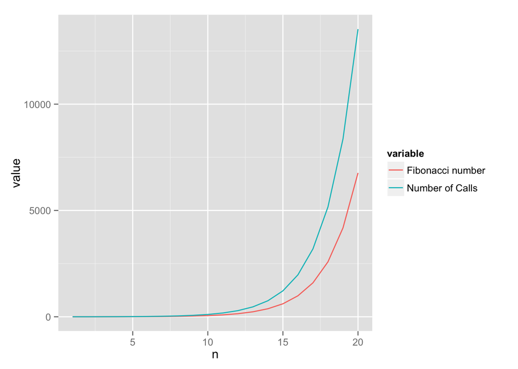

```r
meltres <- reshape2::melt(restab, measure.vars = 2:3)
ggplot(meltres, aes(x = n, y = value, color = variable)) + geom_line()
```

## Factorials!

A factorial is simply the product of n by all the integers that come before it which are nonzero.

### Definition

```r
fact <- function(n, call_count = TRUE){
  if (call_count){
    CALL_COUNTER <<- CALL_COUNTER + 1
  }
  if (n == 1){
    return(1)
  } else {
    fn <- n * fact(n - 1)
    return(fn)
  }
}
```

### Intial tests

```r
fact(1) == 1
```

```
## [1] TRUE
```

```r
fact(2) == 2*1
```

```
## [1] TRUE
```

```r
fact(5) == 5*4*3*2*1
```

```
## [1] TRUE
```

### Table Time

```r
n <- 20
names(restab)[2] <- "Factorial"
for (i in 1:n){
  CALL_COUNTER <- 0
  fact_res      <- fact(i)
  restab[i, ]  <- c(i, fact_res, CALL_COUNTER)
}
```

### Pretty things

```r
knitr::kable(restab)
```

| n | Factorial | Number of Calls |
| --- | --- | --- |
| 1 | 1.000000e+00 | 1 |
| 2 | 2.000000e+00 | 2 |
| 3 | 6.000000e+00 | 3 |
| 4 | 2.400000e+01 | 4 |
| 5 | 1.200000e+02 | 5 |
| 6 | 7.200000e+02 | 6 |
| 7 | 5.040000e+03 | 7 |
| 8 | 4.032000e+04 | 8 |
| 9 | 3.628800e+05 | 9 |
| 10 | 3.628800e+06 | 10 |
| 11 | 3.991680e+07 | 11 |
| 12 | 4.790016e+08 | 12 |
| 13 | 6.227021e+09 | 13 |
| 14 | 8.717829e+10 | 14 |
| 15 | 1.307674e+12 | 15 |
| 16 | 2.092279e+13 | 16 |
| 17 | 3.556874e+14 | 17 |
| 18 | 6.402374e+15 | 18 |
| 19 | 1.216451e+17 | 19 |
| 20 | 2.432902e+18 | 20 |

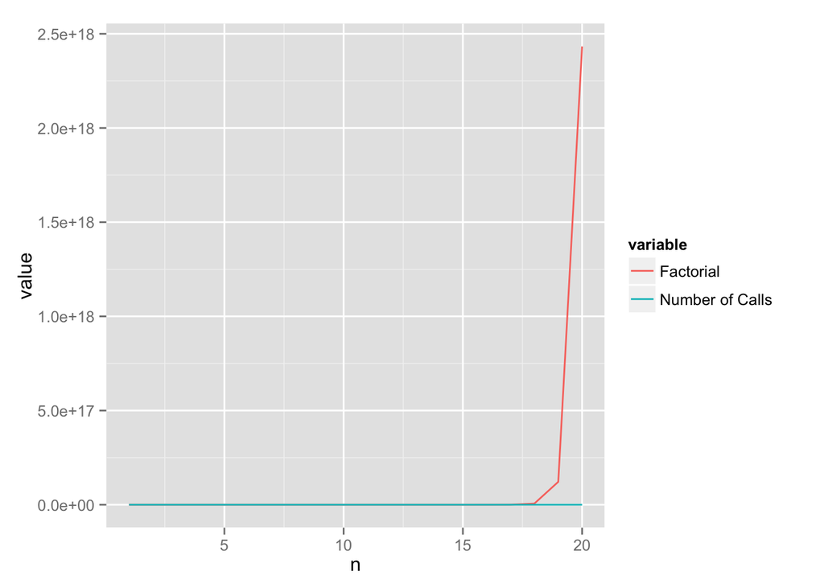

```r
meltres <- reshape2::melt(restab, measure.vars = 2:3)
ggplot(meltres, aes(x = n, y = value, color = variable)) + geom_line()
```

## Terminal function

This one is like the factorial, but it adds numbers instead of multiplies them. This is like taking the last value of a cumulative sum from 1 to n.

```r
tfun <- function(n, call_count = TRUE){
  if (call_count){
    CALL_COUNTER <<- CALL_COUNTER + 1
  }
  if (n == 1){
    return(1)
  } else {
    tn <- n + tfun(n - 1)
    return(tn)
  }
}
```

### Intial tests

```r
tfun(1) == 1
```

```
## [1] TRUE
```

```r
tfun(2) == cumsum(1:2)[2]
```

```
## [1] TRUE
```

```r
tfun(5) == cumsum(1:5)[5]
```

```
## [1] TRUE
```

### Table Time

```r
n <- 20
names(restab)[2] <- "$n^{th}$ triangular number"
for (i in 1:n){
  CALL_COUNTER <- 0
  tfun_res      <- tfun(i)
  restab[i, ]  <- c(i, tfun_res, CALL_COUNTER)
}
```

### Pretty things

```r
knitr::kable(restab)
```

| n | $n^{th}$ triangular number | Number of Calls |
| --- | --- | --- |
| 1 | 1 | 1 |
| 2 | 3 | 2 |
| 3 | 6 | 3 |
| 4 | 10 | 4 |
| 5 | 15 | 5 |
| 6 | 21 | 6 |
| 7 | 28 | 7 |
| 8 | 36 | 8 |
| 9 | 45 | 9 |
| 10 | 55 | 10 |
| 11 | 66 | 11 |
| 12 | 78 | 12 |
| 13 | 91 | 13 |
| 14 | 105 | 14 |
| 15 | 120 | 15 |
| 16 | 136 | 16 |
| 17 | 153 | 17 |
| 18 | 171 | 18 |
| 19 | 190 | 19 |
| 20 | 210 | 20 |

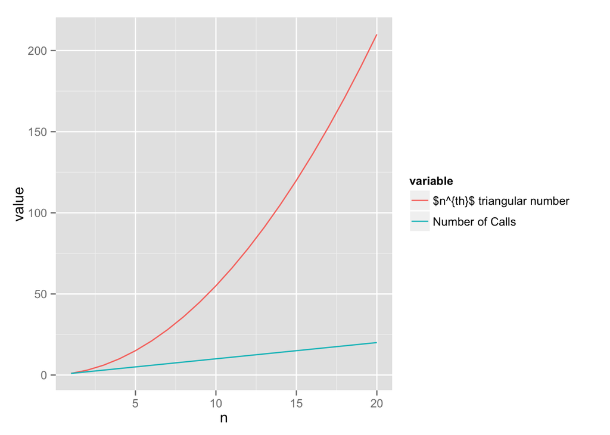

```r
meltres <- reshape2::melt(restab, measure.vars = 2:3)
ggplot(meltres, aes(x = n, y = value, color = variable)) + geom_line()
```